```python
from bs4 import BeautifulSoup
from selenium import webdriver
from IPython.display import Image
import pandas as pd
import folium
import matplotlib.pyplot as plt
import numpy as np
import re
import seaborn as sns
```

```python
# 웹드라이브로 크롬브라우즈 띄운다.
driver_path = "driver/chromedriver.exe"
driver = webdriver.Chrome(executable_path=driver_path)
```

```python
# 스타벅스 웹사이트 url 지정
url_page = 'https://www.starbucks.co.kr/index.do'
driver.get(url_page)
```

# 서울지역 스타벅스 매장정보 크롤링

### 매장 찾기 사이트 이동

```python
url_page = 'https://www.starbucks.co.kr/store/store_map.do'
driver.get(url_page)
```

### 지역검색 클릭

```python
driver.find_element_by_xpath(
    '//*[@id="container"]/div/form/fieldset/div/section/article[1]/article/header[2]/h3/a').click()
```

### 서울 클릭

```python
driver.find_element_by_xpath(
    '//*[@id="container"]/div/form/fieldset/div/section/article[1]/article/article[2]/div[1]/div[2]/ul/li[1]/a').click()
```

### 전체 클릭

```python
driver.find_element_by_xpath(
    '//*[@id="mCSB_2_container"]/ul/li[1]/a').click()
```

### BeautifulSoup을 통해 HTML 정보가져오기

```python
html = driver.page_source
soup = BeautifulSoup(html, "lxml")
```

### 데이터 확인

```python
review_cnt = soup.find("ul","quickSearchResultBoxSidoGugun")
```

```python
re1 = review_cnt.find_all('li')
re1[0].get_text()
```

```
' 역삼아레나빌딩   서울특별시 강남구 언주로 425 (역삼동)1522-3232 리저브 매장 2번'
```

## 스타벅스 매장 이름

```python
starbucks_ul = soup.find("ul","quickSearchResultBoxSidoGugun")
starbucks_li = review_cnt.find_all('li')
starbucks_li[0]['data-name']
```

```
'역삼아레나빌딩'
```

## 스타벅스 매장 주소

```python
starbucks_ul = soup.find("ul","quickSearchResultBoxSidoGugun")
starbucks_li = review_cnt.find_all('li')
starbucks_li[0].find('p','result_details').get_text()[:-9]
```

```
'서울특별시 강남구 언주로 425 (역삼동)'
```

## 매장 소재 구

```python
starbucks_ul = soup.find("ul","quickSearchResultBoxSidoGugun")
starbucks_li = review_cnt.find_all('li')
starbucks_li[0].find('p','result_details').get_text().split()[1]
```

```
'강남구'
```

## 스타벅스 전화번호

```python
starbucks_ul = soup.find("ul","quickSearchResultBoxSidoGugun")
starbucks_li = review_cnt.find_all('li')
starbucks_li[0].find('p','result_details').get_text()[-9:]
```

```
'1522-3232'
```

### For문을 통해 전체 서울 스타벅스 정보 저장하기

```python
sbucksName = []
sbucksGu = []
sbucksAddr = []
sbucksTel = []

starbucks_ul = soup.find("ul","quickSearchResultBoxSidoGugun")
starbucks_li = review_cnt.find_all('li')

for i in range(0,len(review_cnt.find_all('li'))):
    sbucksName.append(starbucks_li[i]['data-name'])
    sbucksAddr.append(starbucks_li[i].find('p','result_details').get_text()[:-9])
    sbucksGu.append(starbucks_li[i].find('p','result_details').get_text().split()[1])
    sbucksTel.append(starbucks_li[i].find('p','result_details').get_text()[-9:])

starbucks = pd.DataFrame({'스타벅스매장':sbucksName,
                          '구'          :sbucksGu,
                          '주소'        :sbucksAddr,
                          '전화번호'    :sbucksTel,
                         })
```

### 저장된 정보 테이블 확인해보기

```python
starbucks.head(10)
```

|  | 스타벅스매장 | 구 | 주소 | 전화번호 |
| --- | --- | --- | --- | --- |
| 0 | 역삼아레나빌딩 | 강남구 | 서울특별시 강남구 언주로 425 (역삼동) | 1522-3232 |
| 1 | 논현역사거리 | 강남구 | 서울특별시 강남구 강남대로 538 (논현동) | 1522-3232 |
| 2 | 신사역성일빌딩 | 강남구 | 서울특별시 강남구 강남대로 584 (논현동) | 1522-3232 |
| 3 | 국기원사거리 | 강남구 | 서울특별시 강남구 테헤란로 125 (역삼동) | 1522-3232 |
| 4 | 스탈릿대치R | 강남구 | 서울특별시 강남구 남부순환로 2947 (대치동) | 1522-3232 |
| 5 | 봉은사역 | 강남구 | 서울특별시 강남구 봉은사로 619 (삼성동) | 1522-3232 |
| 6 | 압구정윤성빌딩 | 강남구 | 서울특별시 강남구 논현로 834 (신사동) | 1522-3232 |
| 7 | 코엑스별마당 | 강남구 | 서울특별시 강남구 영동대로 513 (삼성동) | 1522-3232 |
| 8 | 삼성역섬유센터R | 강남구 | 서울특별시 강남구 테헤란로 518 (대치동) | 1522-3232 |
| 9 | 압구정R | 강남구 | 서울특별시 강남구 언주로 861 (신사동) | 1522-3232 |

# 서울인구 정보를 가져온 후 스타벅스지표를 나타낸다.

## 인구데이터 불러오기

```python
df_pop = pd.read_excel('data/Report_seoul_population_2019_2Q.xls') #2019년 인구데이터 불러오기
df=df_pop[['자치구','인구']][-25:] #불필요한 데이터 제외
df['인구'].astype(int) #인구를 정수 타입으로 변환
df = df.set_index("자치구") #자치구를 인덱스로 설정
df.sort_values(by=["인구"],ascending=False) #인구가 많은 순으로 자치구 정렬
```

| 자치구 | 인구 |
| --- | --- |
| 송파구 | 686181 |
| 강서구 | 602230 |
| 강남구 | 547602 |
| 노원구 | 542603 |
| 관악구 | 519864 |
| 은평구 | 488285 |
| 양천구 | 465095 |
| 성북구 | 452292 |
| 구로구 | 439328 |
| 서초구 | 435631 |
| 강동구 | 428547 |
| 동작구 | 412000 |
| 중랑구 | 405639 |
| 영등포구 | 404229 |
| 마포구 | 385985 |
| 광진구 | 369470 |
| 동대문구 | 363101 |
| 도봉구 | 339001 |
| 서대문구 | 324304 |
| 강북구 | 319377 |
| 성동구 | 312991 |
| 금천구 | 254061 |
| 용산구 | 245069 |
| 종로구 | 162413 |
| 중구 | 136276 |

### Matplotlib 한글폰트 지정

```python
import matplotlib.font_manager as fm

font_location = 'font/NanumGothic.ttf'
font_name = fm.FontProperties(fname=font_location).get_name()
font_name
```

```
'NanumGothic'
```

```python
df.sort_values(by=["인구"],ascending=False)
df1 = df.reset_index()
df1 = df1.sort_values(by=["인구"],ascending=False)
x = df1["자치구"]
y = df1["인구"]
```

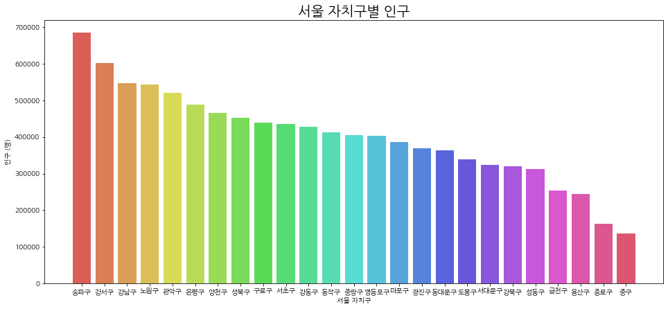

```python
plt.figure(figsize=(16, 7)) ## 그래프사이즈설정
colors = sns.color_palette('hls',len(x)) ##씨본에서 제공하는 색팔레트


plt.bar(x,y,color=colors)

plt.title('서울 자치구별 인구',fontsize=20) ## 타이틀 출력
plt.xlabel('서울 자치구') ## x축 라벨 출력
plt.ylabel('인구 (명)') ## y축 라벨 출력
plt.rc('font', family='NanumGothic') ## 한글깨짐 폰트 변경

plt.show()
```

# 데이터 시각화 FOLIUM

```python
import folium

import pandas as pd
import json
import warnings
warnings.simplefilter(action = "ignore", category = FutureWarning)
```

```python
geo_path = 'data/skorea_municipalities_geo_simple.json'
geo_str  = json.load(open(geo_path, encoding='utf-8'))
```

```python
map = folium.Map(location=[37.5502, 126.982], tiles='Stamen Toner', zoom_start=11)

map.choropleth(geo_data=geo_str,
               data=df,
               columns=[df.index, '인구'],
               fill_color='BuPu',
               key_on='feature.id')
map
```

Make this Notebook Trusted to load map: File -> Trust Notebook

[interactive chart not shown]

```python
df1.head(5)
```

|  | 자치구 | 인구 |
| --- | --- | --- |
| 23 | 송파구 | 686181 |
| 15 | 강서구 | 602230 |
| 22 | 강남구 | 547602 |
| 10 | 노원구 | 542603 |
| 20 | 관악구 | 519864 |

## 서울에서 가장 많은 인구가 사는 지역은 송파구로 2019년 기준 686,181명이었으며, 뒤따라 강서구, 강남구 순이다. 가장 인구가 적은 지역은 중구로 136,276명으로 송파구와는 대략 5배 차이가 난다.

## 스벅비율 계산

```python
df_sb=starbucks.groupby('구').count()['스타벅스매장']
```

```python
df = pd.merge(df,df_sb,left_index=True,right_index=True)
```

```python
df.rename(columns = {'스타벅스매장' : '스타벅스'}, inplace = True)
df['스벅비율'] = 1000000*df['스타벅스']/df['인구']
df.sort_values(by='스타벅스', ascending=False)
```

|  | 인구 | 스타벅스 | 스벅비율 |
| --- | --- | --- | --- |
| 강남구 | 547602 | 84 | 153.396 |
| 중구 | 136276 | 54 | 396.255 |
| 서초구 | 435631 | 47 | 107.889 |
| 종로구 | 162413 | 38 | 233.971 |
| 영등포구 | 404229 | 34 | 84.1107 |
| 마포구 | 385985 | 33 | 85.4956 |
| 송파구 | 686181 | 32 | 46.6349 |
| 용산구 | 245069 | 20 | 81.6097 |
| 서대문구 | 324304 | 19 | 58.587 |
| 강서구 | 602230 | 16 | 26.5679 |
| 광진구 | 369470 | 16 | 43.3053 |
| 강동구 | 428547 | 16 | 37.3355 |
| 양천구 | 465095 | 15 | 32.2515 |
| 성북구 | 452292 | 13 | 28.7425 |
| 노원구 | 542603 | 12 | 22.1156 |
| 구로구 | 439328 | 11 | 25.0382 |
| 금천구 | 254061 | 11 | 43.2967 |
| 동작구 | 412000 | 11 | 26.699 |
| 관악구 | 519864 | 11 | 21.1594 |
| 성동구 | 312991 | 11 | 35.1448 |
| 은평구 | 488285 | 8 | 16.3839 |
| 중랑구 | 405639 | 8 | 19.722 |
| 동대문구 | 363101 | 8 | 22.0324 |
| 강북구 | 319377 | 5 | 15.6555 |
| 도봉구 | 339001 | 2 | 5.89969 |

# 스벅비율 및 스벅매장수를 서울시 지도에 시각화

```python
map = folium.Map(location=[37.5502, 126.982], tiles='Stamen Toner', zoom_start=11)

map.choropleth(geo_data=geo_str,
               data=df,
               columns=[df.index, '스타벅스'],
               fill_color='PuRd',
               key_on='feature.id')
map
```

Make this Notebook Trusted to load map: File -> Trust Notebook

[interactive chart not shown]

# 인구대비 스벅비율

```python
map = folium.Map(location=[37.5502, 126.982], tiles='Stamen Toner', zoom_start=11)

map.choropleth(geo_data=geo_str,
               data=df,
               columns=[df.index, '스벅비율'],
               fill_color='YlGnBu',
               key_on='feature.id')
map
```

Make this Notebook Trusted to load map: File -> Trust Notebook

[interactive chart not shown]

# 스벅이 많은 순으로 정렬

```python
df.sort_values(by=["스타벅스"],ascending=False)
```

|  | 인구 | 스타벅스 | 스벅비율 |
| --- | --- | --- | --- |
| 강남구 | 547602 | 84 | 153.396 |
| 중구 | 136276 | 54 | 396.255 |
| 서초구 | 435631 | 47 | 107.889 |
| 종로구 | 162413 | 38 | 233.971 |
| 영등포구 | 404229 | 34 | 84.1107 |
| 마포구 | 385985 | 33 | 85.4956 |
| 송파구 | 686181 | 32 | 46.6349 |
| 용산구 | 245069 | 20 | 81.6097 |
| 서대문구 | 324304 | 19 | 58.587 |
| 강서구 | 602230 | 16 | 26.5679 |
| 광진구 | 369470 | 16 | 43.3053 |
| 강동구 | 428547 | 16 | 37.3355 |
| 양천구 | 465095 | 15 | 32.2515 |
| 성북구 | 452292 | 13 | 28.7425 |
| 노원구 | 542603 | 12 | 22.1156 |
| 구로구 | 439328 | 11 | 25.0382 |
| 금천구 | 254061 | 11 | 43.2967 |
| 동작구 | 412000 | 11 | 26.699 |
| 관악구 | 519864 | 11 | 21.1594 |
| 성동구 | 312991 | 11 | 35.1448 |
| 은평구 | 488285 | 8 | 16.3839 |
| 중랑구 | 405639 | 8 | 19.722 |
| 동대문구 | 363101 | 8 | 22.0324 |
| 강북구 | 319377 | 5 | 15.6555 |
| 도봉구 | 339001 | 2 | 5.89969 |

```python
sum(df["스타벅스"]) #서울 전체 스타벅스 개수
```

```
535
```

### 스타벅스가 가장많은 지역은 강남구로 84개가 있으며, 이는 서울 전체 535중 15%에 해당한다. 가장 적은 지역인 도봉구는 2개로 강남구와 큰 차이를 보였다.

# 인구대비 스타벅스가 많은 순으로 정렬

```python
df.sort_values(by=["스벅비율"],ascending=False)
```

|  | 인구 | 스타벅스 | 스벅비율 |
| --- | --- | --- | --- |
| 중구 | 136276 | 54 | 396.255 |
| 종로구 | 162413 | 38 | 233.971 |
| 강남구 | 547602 | 84 | 153.396 |
| 서초구 | 435631 | 47 | 107.889 |
| 마포구 | 385985 | 33 | 85.4956 |
| 영등포구 | 404229 | 34 | 84.1107 |
| 용산구 | 245069 | 20 | 81.6097 |
| 서대문구 | 324304 | 19 | 58.587 |
| 송파구 | 686181 | 32 | 46.6349 |
| 광진구 | 369470 | 16 | 43.3053 |
| 금천구 | 254061 | 11 | 43.2967 |
| 강동구 | 428547 | 16 | 37.3355 |
| 성동구 | 312991 | 11 | 35.1448 |
| 양천구 | 465095 | 15 | 32.2515 |
| 성북구 | 452292 | 13 | 28.7425 |
| 동작구 | 412000 | 11 | 26.699 |
| 강서구 | 602230 | 16 | 26.5679 |
| 구로구 | 439328 | 11 | 25.0382 |
| 노원구 | 542603 | 12 | 22.1156 |
| 동대문구 | 363101 | 8 | 22.0324 |
| 관악구 | 519864 | 11 | 21.1594 |
| 중랑구 | 405639 | 8 | 19.722 |
| 은평구 | 488285 | 8 | 16.3839 |
| 강북구 | 319377 | 5 | 15.6555 |
| 도봉구 | 339001 | 2 | 5.89969 |

### 인구대비 스타벅스가 가장 많은 지역은 중구로 54개의 스타벅스가 있어서, 강남의 84개보다 작지만 인구가 강남에 비해 상당히 낮기 때문에, 인구 대비 스타벅스의 비율이 가장 높았다. 그 다음으로는 종로구 였는데, 역시 스타벅스의 개수는 38개로 강남의 84개에 비해 현저히 낮지만, 인구가 작기 때문에 스타벅스의 비율은 강남 보다 높았다. 이는, 중구,종로구에 유동인구가 많음으로 설명 가능하다.